# Explorando los datos

## Voltaje estimulaciones VS. tiempo entre inicio y último seguimiento

```r
cor(chuvi$Tiempo.inicio.ultimo.seguimiento, chuvi$VA, use="complete.obs")
```

```
[1] -0.6754928
```

Esta vez el valor no es muy alto, pero podemos ver que al menos es más alto que los valores anteriores. Hay una cierta correlación.

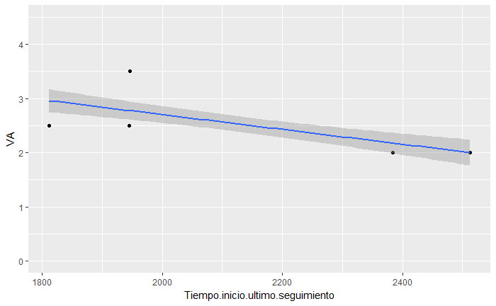

```r
library(ggplot2)
ggplot(chuvi, aes(x=Tiempo.inicio.ultimo.seguimiento, y=VA)) + geom_point() + stat_smooth(method="lm")
```

```r
cor(chuvi$Tiempo.inicio.ultimo.seguimiento, chuvi$VD, use="complete.obs")
```

```
[1] -0.8839702
```

Esta vez vemos un valor de correlación inversa muy alto, pero no deberíamos fiarnos demasiado porque solo tenemos cinco datos.

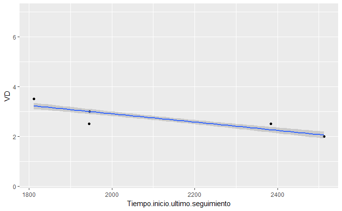

```r
library(ggplot2)
ggplot(chuvi, aes(x=Tiempo.inicio.ultimo.seguimiento, y=VD)) + geom_point() + stat_smooth(method="lm")
```

```r
cor(chuvi$Tiempo.inicio.ultimo.seguimiento, chuvi$VI, use="complete.obs")
```

```
[1] -0.5699523
```

Un valor de correlación relativamente alto, pero no demasiado. Esto, añadiendo el hecho de que casi no tenemos datos, hace que no queramos fiarnos mucho de los resultados.

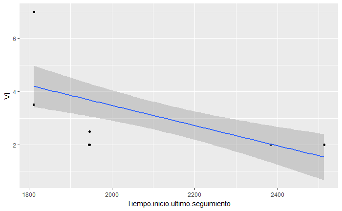

```r
library(ggplot2)
ggplot(chuvi, aes(x=Tiempo.inicio.ultimo.seguimiento, y=VI)) + geom_point() + stat_smooth(method="lm")
```

Bueno, como soy muy lista había puesto límite 2000 y así claro que no se veía nada. Tenemos muy pocos datos para poder sacar conclusiones fehacientes, pero parece haber una relación entre la duración de la batería y el voltaje de las distintas cámaras. Cuanto mayor es el voltaje, menor es la duración.

Tiempo entre inicio y último seguimiento vs. MSVA, etc.

```r
cor(chuvi$Tiempo.inicio.ultimo.seguimiento, chuvi$MSA, use="complete.obs")
```

```
the standard deviation is zero
```

```
[1] NA
```

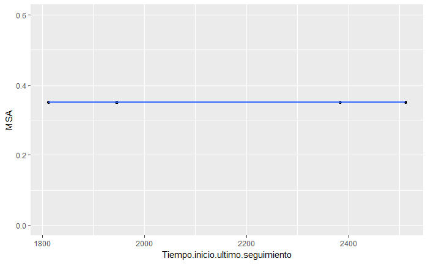

```r
library(ggplot2)
ggplot(chuvi, aes(x=Tiempo.inicio.ultimo.seguimiento, y=MSA)) + geom_point() + stat_smooth(method="lm")
```

```r
cor(chuvi$Tiempo.inicio.ultimo.seguimiento, chuvi$MSVD, use="complete.obs")
```

```
[1] -0.3554288
```

Una correlación tan baja que no podemos asumir que hay relación real, sobre todo asumiendo la falta de datos.

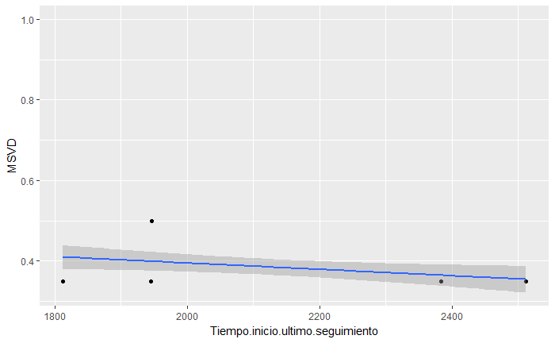

```r
library(ggplot2)
ggplot(chuvi, aes(x=Tiempo.inicio.ultimo.seguimiento, y=MSVD)) + geom_point() + stat_smooth(method="lm")
```

```r
cor(chuvi$Tiempo.inicio.ultimo.seguimiento, chuvi$MSVI, use="complete.obs")
```

```
[1] -0.5234936
```

Esta vez la correlación es un poco mejor, pero tampoco deberíamos tomárnoslos muy en serio teniendo en cuenta la cantidad de datos.

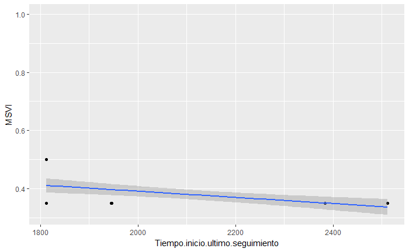

```r
library(ggplot2)
ggplot(chuvi, aes(x=Tiempo.inicio.ultimo.seguimiento, y=MSVI)) + geom_point() + stat_smooth(method="lm")
```

Número de cámaras VS. Tiempo entre inicio y fin

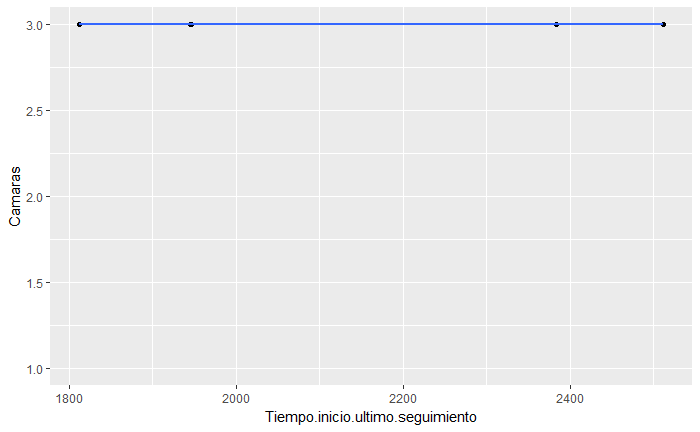

```r
library(ggplot2)
ggplot(chuvi, aes(x=Tiempo.inicio.ultimo.seguimiento, y=Camaras)) + geom_point() + stat_smooth(method="lm")
```

Como no tenemos ningún dato de tiempo final para el número de cámaras, no sabemos si afecta. Maravilloso.

Frecuencia mínima VS. Tiempo

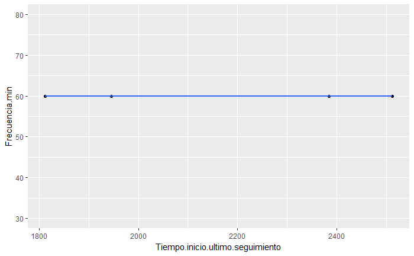

```r
library(ggplot2)
ggplot(chuvi, aes(x=Tiempo.inicio.ultimo.seguimiento, y=Frecuencia.min)) + geom_point() + stat_smooth(method="lm")
```

Hmmmmmgenial

Choque, ATP y R: ya ni me molesto en ponerlas: no aparece ningún dato en las gráficas.

## Tiempo hasta el último seguimiento

```r
cor(chuvi$Tiempo.hasta.ultimo.seguimiento, chuvi$STIMA, use="complete.obs")
```

```
[1] -0.01374414
```

No correlation.

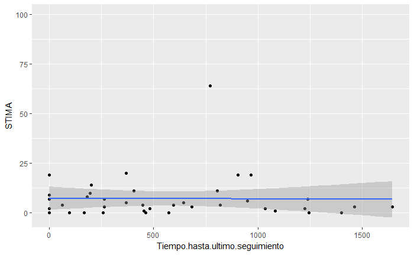

```r
library(ggplot2)
ggplot(chuvi, aes(x=Tiempo.hasta.ultimo.seguimiento, y=STIMA)) + geom_point() + stat_smooth(method="lm")
```

```r
cor(chuvi$Tiempo.hasta.ultimo.seguimiento, chuvi$STIMVD, use="complete.obs")
```

```
[1] -0.05644534
```

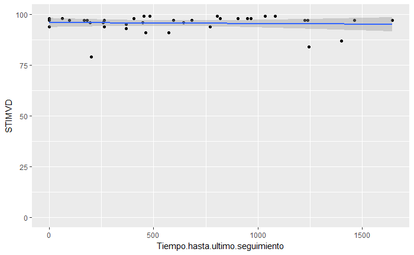

```r
library(ggplot2)
ggplot(chuvi, aes(x=Tiempo.hasta.ultimo.seguimiento, y=STIMVD)) + geom_point() + stat_smooth(method="lm")
```

```r
cor(chuvi$Tiempo.hasta.ultimo.seguimiento, chuvi$STIMVI, use="complete.obs")
```

```
[1] -0.05644534
```

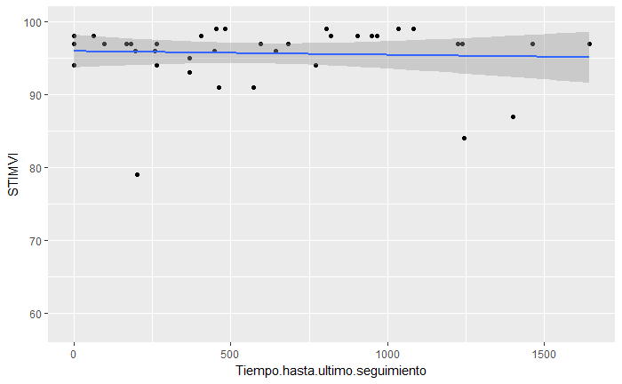

```r
library(ggplot2)
ggplot(chuvi, aes(x=Tiempo.hasta.ultimo.seguimiento, y=STIMVI)) + geom_point() + stat_smooth(method="lm")
```

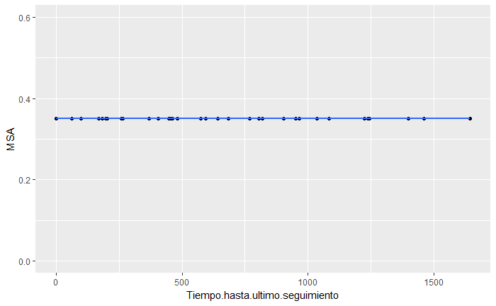

```r
library(ggplot2)
ggplot(chuvi, aes(x=Tiempo.hasta.ultimo.seguimiento, y=MSA)) + geom_point() + stat_smooth(method="lm")
```

```r
cor(chuvi$Tiempo.hasta.ultimo.seguimiento, chuvi$MSVD, use="complete.obs")
```

```
[1] -0.03607605
```

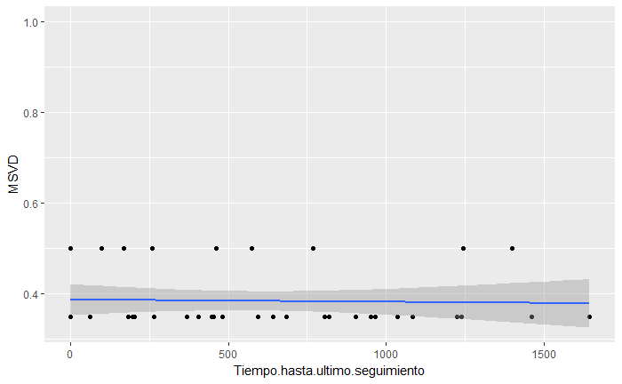

```r
library(ggplot2)
ggplot(chuvi, aes(x=Tiempo.hasta.ultimo.seguimiento, y=MSVD)) + geom_point() + stat_smooth(method="lm")
```

```r
cor(chuvi$Tiempo.hasta.ultimo.seguimiento, chuvi$MSVI, use="complete.obs")
```

```
[1] -0.072241
```

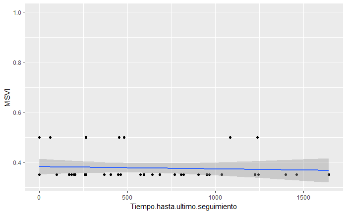

```r
library(ggplot2)
ggplot(chuvi, aes(x=Tiempo.hasta.ultimo.seguimiento, y=MSVI)) + geom_point() + stat_smooth(method="lm")
```

```r
cor(chuvi$Tiempo.hasta.ultimo.seguimiento, chuvi$VA, use="complete.obs")
```

```
[1] -0.06193702
```

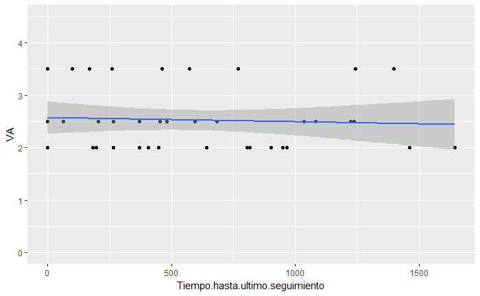

```r
library(ggplot2)
ggplot(chuvi, aes(x=Tiempo.hasta.ultimo.seguimiento, y=VA)) + geom_point() + stat_smooth(method="lm")
```

```r
cor(chuvi$Tiempo.hasta.ultimo.seguimiento, chuvi$VD, use="complete.obs")
```

```
[1] -0.1046722
```

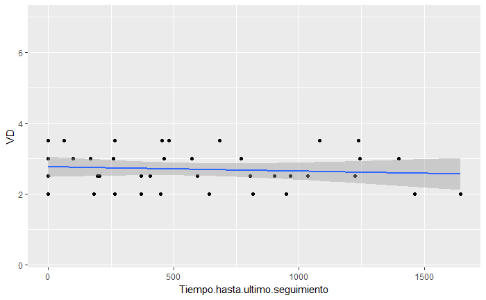

```r
library(ggplot2)
ggplot(chuvi, aes(x=Tiempo.hasta.ultimo.seguimiento, y=VD)) + geom_point() + stat_smooth(method="lm")
```

```r
cor(chuvi$Tiempo.hasta.ultimo.seguimiento, chuvi$VI, use="complete.obs")
```

```
[1] -0.07254442
```

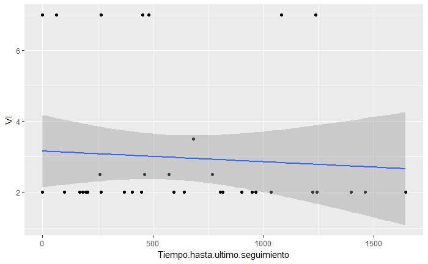

```r
library(ggplot2)
ggplot(chuvi, aes(x=Tiempo.hasta.ultimo.seguimiento, y=VI)) + geom_point() + stat_smooth(method="lm")
```

No hay mucha correlación entre cuánto dura la batería desde un punto concreto y la programación de esto (cosa que, dentro de lo que cabe, tiene sentido, pues son valores que se mantienen y no van cambiando según cuánta vida le queda a la batería). Lo mismo pasa con todos los valores de programación.

## Supervivencia

Supervivencia VS. Estimulaciones

No me está queriendo pintar las gráficas porque faltan demasiados valores lmao.

## Supervivencia distintos meses

Supervviencia meses vs. voltaje

```r
cor(chuvi$Voltaje.bateria, as.numeric(chuvi$x3M.factor), use="complete.obs")
```

```
[1] 0.04736133
```

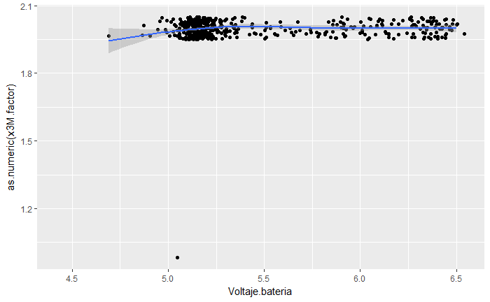

```r
ggplot(chuvi, aes(x=Voltaje.bateria, y=as.numeric(x3M.factor))) +
geom_point(position=position_jitter(w=0.05, h=0.05)) +
geom_smooth()
```

```r
cor(chuvi$Voltaje.bateria, as.numeric(chuvi$x6M.factor), use="complete.obs")
```

```
[1] 0.0861797
```

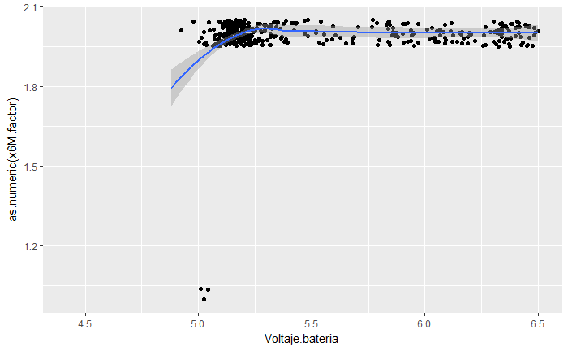

```r
ggplot(chuvi, aes(x=Voltaje.bateria, y=as.numeric(x6M.factor))) +
geom_point(position=position_jitter(w=0.05, h=0.05)) +
geom_smooth()
```

```r
cor(chuvi$Voltaje.bateria, as.numeric(chuvi$x12M.factor), use="complete.obs")
```

```
[1] 0.1661591
```

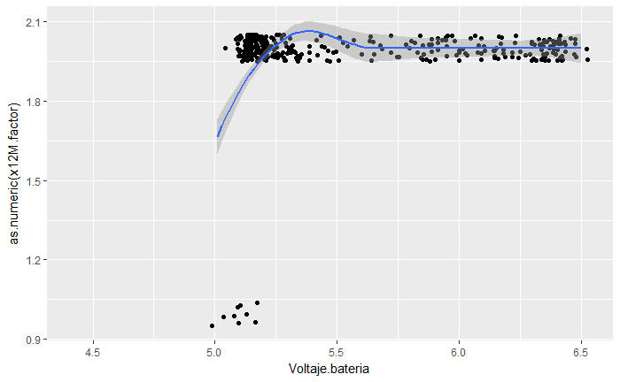

```r
ggplot(chuvi, aes(x=Voltaje.bateria, y=as.numeric(x12M.factor))) +
geom_point(position=position_jitter(w=0.05, h=0.05)) +
geom_smooth()
```

```r
cor(chuvi$Voltaje.bateria, as.numeric(chuvi$x18M.factor), use="complete.obs")
```

```
[1] 0.2633239
```

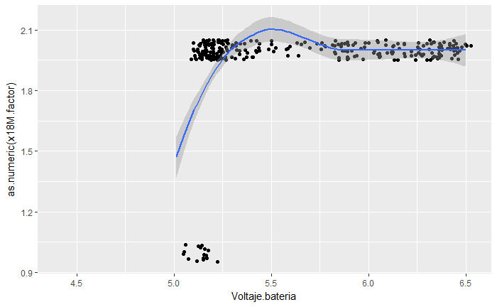

```r
ggplot(chuvi, aes(x=Voltaje.bateria, y=as.numeric(x18M.factor))) +
geom_point(position=position_jitter(w=0.05, h=0.05)) +
geom_smooth()
```

Supervivencia vs. estimulaciones

```r
cor(chuvi$STIMA, as.numeric(chuvi$x3M.factor), use="complete.obs")
```

```
[1] 0.04174858
```

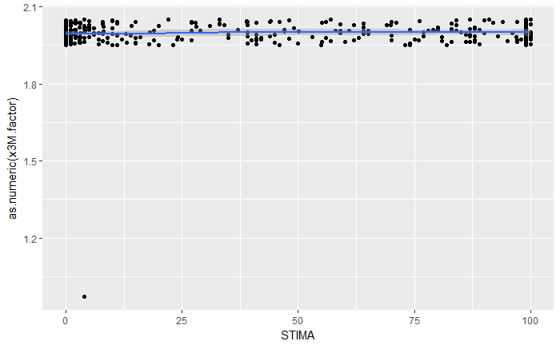

```r
ggplot(chuvi, aes(x=STIMA, y=as.numeric(x3M.factor))) +
geom_point(position=position_jitter(w=0.05, h=0.05)) +
geom_smooth()
```

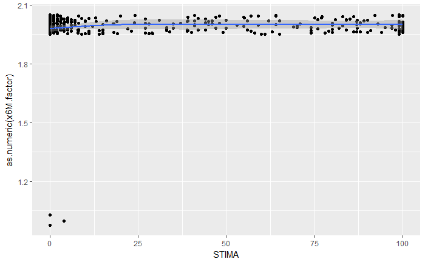

```r
ggplot(chuvi, aes(x=STIMA, y=as.numeric(x6M.factor))) +
geom_point(position=position_jitter(w=0.05, h=0.05)) +
geom_smooth()
```

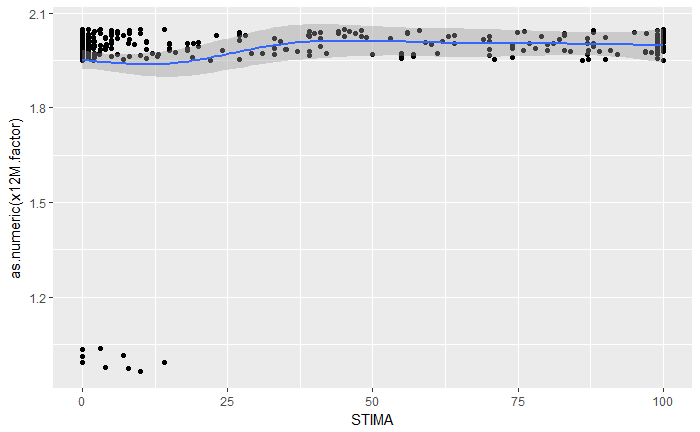

```r
ggplot(chuvi, aes(x=STIMA, y=as.numeric(x12M.factor))) +
geom_point(position=position_jitter(w=0.05, h=0.05)) +
geom_smooth()
```

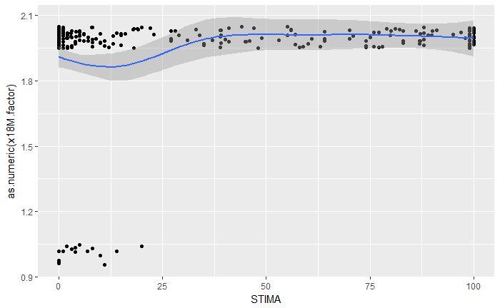

```r
ggplot(chuvi, aes(x=STIMA, y=as.numeric(x18M.factor))) +
geom_point(position=position_jitter(w=0.05, h=0.05)) +
geom_smooth()
```

A pesar de la pequeña cantidad de datos no podemos evitar ver la relación entre que haya un valor pequeño y que haya más probabilidades de sobrevivir? No tengo muy claro qué significa cada uno de los dos?

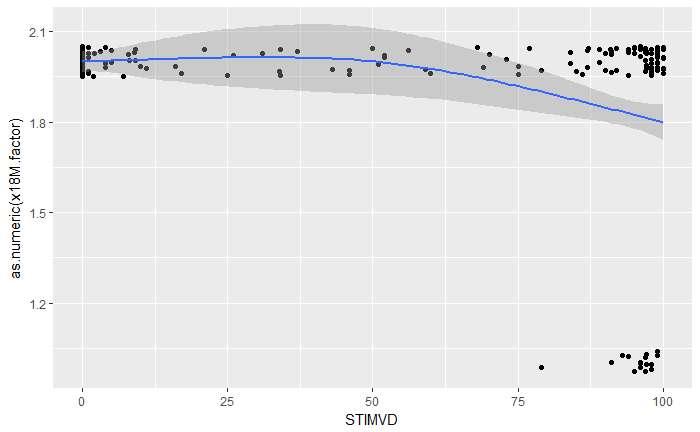

```r
ggplot(chuvi, aes(x=STIMVD, y=as.numeric(x18M.factor))) +
geom_point(position=position_jitter(w=0.05, h=0.05)) +
geom_smooth()
```

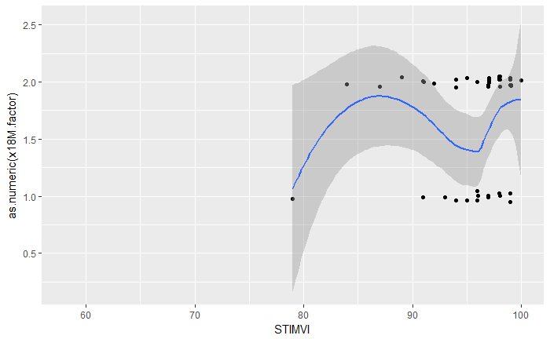

```r
ggplot(chuvi, aes(x=STIMVI, y=as.numeric(x18M.factor))) +
geom_point(position=position_jitter(w=0.05, h=0.05)) +
geom_smooth()
```

Estos resultados son bastante extraños y no sé qué conclusiones sacar de ellos, la verdad.

## Revisión

Heos descubierto que los valores de programación no son tal, así que vamos a rehacer unas gráficas.

STIMS: Los STIMS no son valores programados: cambian cada vez. Creo que puede haber relación con la bajada de voltaje desde la cita anterior hasta la actual, pero como eso no tiene sentido que lo miremos…

## ESTIMULACIONES

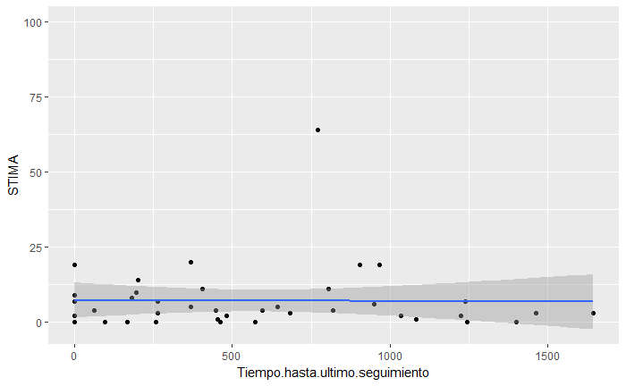

```r
library(ggplot2)
ggplot(chuvi, aes(x=Tiempo.hasta.ultimo.seguimiento, y=STIMA)) + geom_point() + stat_smooth(method="lm")
```

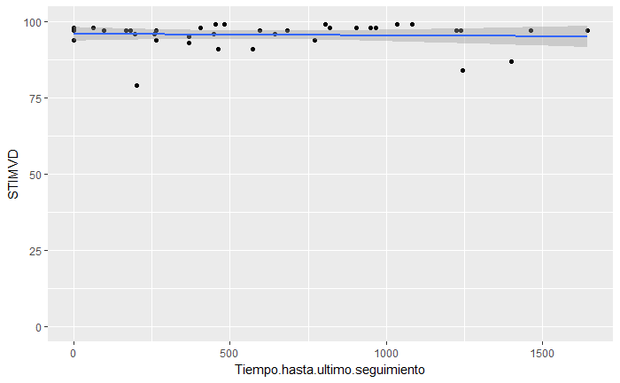

```r
library(ggplot2)
ggplot(chuvi, aes(x=Tiempo.hasta.ultimo.seguimiento, y=STIMVD)) + geom_point() + stat_smooth(method="lm")
```

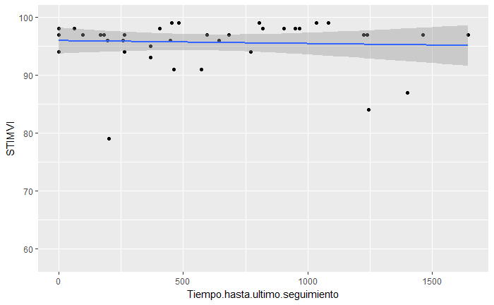

```r
library(ggplot2)
ggplot(chuvi, aes(x=Tiempo.hasta.ultimo.seguimiento, y=STIMVI)) + geom_point() + stat_smooth(method="lm")
```

Bueno, o sea, que no hay relación. Es bueno saberlo.

## VAs

```r
cor(chuvi$Voltaje.bateria,chuvi$VA, use="complete.obs")
```

```
[1] 0.209294
```

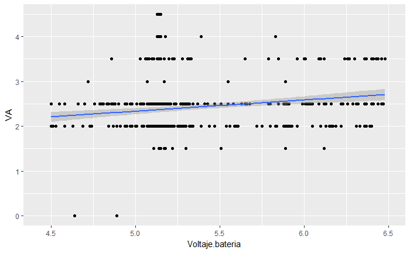

```r
library(ggplot2)
ggplot(chuvi, aes(x=Voltaje.bateria, y=VA)) + geom_point() + stat_smooth(method="lm")
```

```r
cor(chuvi$Voltaje.bateria,chuvi$MSA, use="complete.obs")
```

```
[1] -0.1033818
```

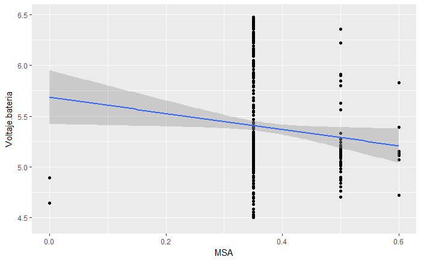

```r
library(ggplot2)
ggplot(chuvi, aes(x=MSA, y=Voltaje.bateria)) + geom_point() + stat_smooth(method="lm")
```

## Conclusiones

De este análisis sacamos unas cuantas conclusiones:

- Los datos no son ideales
- La mayor variedad de datos la tenemos para las 3 cámaras, pero la mayor cantidad de datos la tenemos para las 2 cámaras.
- La evolución del voltaje con respecto al tiempo es bastante interesante.
- El voltaje de la batería, así como los parámetros de estimulación, parecen tener relación con la supervivencia de la batería.